# 02. Studying the laws that determine success of the games.

The online store "Streamchik" sells computer games all over the world. Historical data on game sales, user and expert ratings, genres and platforms (for example, Xbox or PlayStation) are available from open sources. We need to identify the patterns that determine the success of the game. This will allow you to bet on a potentially popular product and plan advertising campaigns.

Upon the data before 2016, we are planning a campaign for 2017. The dataframe will be preprocessed below, data gaps will be removed and filled in, graphs will be constructed, the interdependencies of indicators will be investigated, correlation calculated, statistical hypotheses tested, etc. Let's get started.

## Preprocessing and preliminary analysis.

### Description of the data (columns).

- Name — the name of the game
- Platform — platform
- Year_of_Release — year of release
- Genre — the genre of the game
- NA_sales — sales in North America (millions of copies sold)
- EU_sales — sales in Europe (millions of copies sold)
- JP_sales — sales in Japan (millions of copies sold)
- Other_sales — sales in other countries (millions of copies sold)
- Critic_Score — critics' score (maximum 100)
- User_Score — user rating (maximum 10)
- Rating — rating from the ESRB organization (Eng. Entertainment Software Rating Board). This association determines the rating of computer games and assigns them a suitable age category.

Addition. The codes are assigned by the American ESRB organization. Assignment is on a voluntary basis, a significant part of the games do not have codes. The designations "from children's to adult content": EC, E, E10+, T, M, AO and the so-called "pending pseudo-rating" RP.

A few comments.

- Sales are not given in monetary terms, but in pieces. In addition, for each game, sales are calculated cumulatively (cumulative total) from the release date of the game to the present (2016).
- This prevents us from dividing sales by games within the allocated period (regardless of when they were released) and it turns out that we are rather dealing not with sales for the year, as is usually customary, but with the result of sales for the entire period of the game's existence.
- Such a frame of reference has the following drawback: a game that has not been sold at all for the last 5 years can remain at the top of sales, generally speaking, indefinitely, and it is impossible to single out promising, fast-growing newcomers with such a system of accounting.
- The system is conservative, for marketing it lacks a typical layout of sales volumes. In the analysis below, the words "growing", "falling" can be used - however, the meaning of these words is more accurately expressed as "more" and "less". For example: "as of 2016, the number of games sold released in 2005 (11 years of sales) is less than the number of games released in 2008 (8 years of sales)."

### Step 1. Loading the data. Histograms by dataset columns.

```python
# import of the libraries necessary for analysis and plotting

import seaborn as sns
import matplotlib
import matplotlib.pyplot as plt
import numpy as np
import pandas as pd
import random
import os
from scipy import stats as st
```

```python
# let's define the file search function in Linux and Windows folders (if the notebook works locally)

def file_path(name):
    """
File search function (lowercase file name is the function argument) in Linux and Windows folders
 (if the notebook works locally).

We read the data file with an attempt to take data locally: 4 attempts for the Yandex-server and
Windows. The file should be located next to the notebook or in the nested directory "datasets".
    """
    for p in ('/datasets', '', os.path.abspath(""), os.path.abspath("")+'\\datasets\\'):
        pth1 = os.path.join(p, name)
        if os.path.exists(pth1):
            break # if the search is successful, we break the cycle ahead of schedule
    else:
        pth1 = ''
        print(f"The {name} file wasn't found. Make sure that it",
              'is present in the directory next to the notebook or in a subfolder "/datasets"')
    print('Data reading from:', pth1, '\n')
    return pth1


name = 'games.csv' # the name of the file to be found and read
data = pd.read_csv(file_path(name))  # writing a data file to a dataframe
```

```
Data reading from: games.csv
```

```python
data.info()   # general information on the data set
```

```
<class 'pandas.core.frame.DataFrame'>
RangeIndex: 16715 entries, 0 to 16714
Data columns (total 11 columns):
 #   Column           Non-Null Count  Dtype
---  ------           --------------  -----
 0   Name             16713 non-null  object
 1   Platform         16715 non-null  object
 2   Year_of_Release  16446 non-null  float64
 3   Genre            16713 non-null  object
 4   NA_sales         16715 non-null  float64
 5   EU_sales         16715 non-null  float64
 6   JP_sales         16715 non-null  float64
 7   Other_sales      16715 non-null  float64
 8   Critic_Score     8137 non-null   float64
 9   User_Score       10014 non-null  object
 10  Rating           9949 non-null   object
dtypes: float64(6), object(5)
memory usage: 1.4+ MB
```

```python
data.head()   # first 5 rows of dataset
```

|  | Name | Platform | Year_of_Release | Genre | NA_sales | EU_sales | JP_sales | Other_sales | Critic_Score | User_Score | Rating |
| --- | --- | --- | --- | --- | --- | --- | --- | --- | --- | --- | --- |
| 0 | Wii Sports | Wii | 2006.0 | Sports | 41.36 | 28.96 | 3.77 | 8.45 | 76.0 | 8 | E |
| 1 | Super Mario Bros. | NES | 1985.0 | Platform | 29.08 | 3.58 | 6.81 | 0.77 | NaN | NaN | NaN |
| 2 | Mario Kart Wii | Wii | 2008.0 | Racing | 15.68 | 12.76 | 3.79 | 3.29 | 82.0 | 8.3 | E |
| 3 | Wii Sports Resort | Wii | 2009.0 | Sports | 15.61 | 10.93 | 3.28 | 2.95 | 80.0 | 8 | E |
| 4 | Pokemon Red/Pokemon Blue | GB | 1996.0 | Role-Playing | 11.27 | 8.89 | 10.22 | 1.00 | NaN | NaN | NaN |

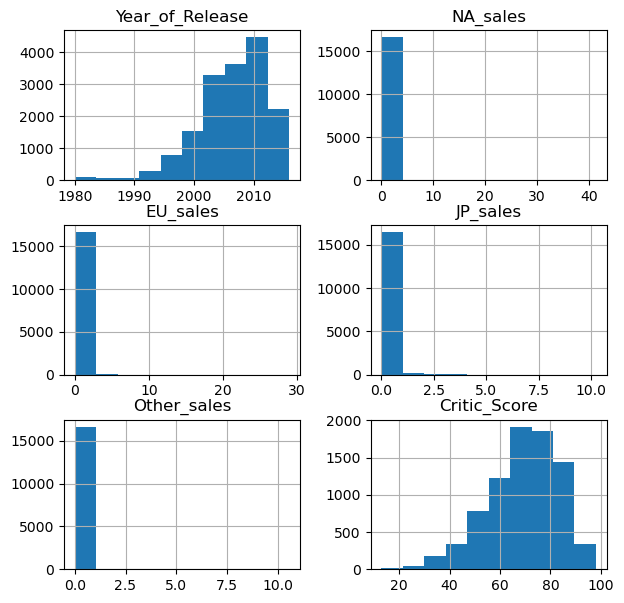

```python
# histograms by columns

data.hist(figsize=(7, 7))

from IPython.core.display import display, HTML
display(HTML("<style>div.output_scroll { height: 45em; }</style>"))
```

### Step 2. Data preparation. Processing of omissions.

#### Lowercase translation of column names.

```python
# bringing the column names to lower case

# data.columns = [col.lower() for col in data.columns]
data.columns = data.columns.str.lower()
data.columns
```

```
Index(['name', 'platform', 'year_of_release', 'genre', 'na_sales', 'eu_sales',
       'jp_sales', 'other_sales', 'critic_score', 'user_score', 'rating'],
      dtype='object')
```

#### Search and delete duplicates.

```python
data.duplicated().sum()  # number of duplicates
```

```
0
```

```python
data = data.drop_duplicates() # removinging duplicetes
```

#### Processing of missing data on games.

232 games do not have a release year. It is very time-consuming to manually restore the years of vyska for 230 games according to Wikipedia. Writing a program to automatically search for data on the web and fill in the gaps is beyond the scope of our project.

The most logical reason for the lack of release dates is that the games are quite old, and statistics on the year of release were added later. However, an Internet search for randomly selected 10 games gives the release years 2001, 2002, 2005, 2006, 2007, 2008, 2009, 2011, 2017 - therefore, it is more logical to assume some technical reason for the lack of data or intentional mashing of data for the educational task of this project.

```python
# data[data['year_of_release'].isna()]['name'].nunique()  # number of games without a release year
# names of games without release year, it will definitely not work to process everything manually
data[data['year_of_release'].isna()]['name'].unique()
```

```
array(['Madden NFL 2004', 'FIFA Soccer 2004',
       'LEGO Batman: The Videogame', 'wwe Smackdown vs. Raw 2006',
       'Space Invaders', 'Rock Band',
       "Frogger's Adventures: Temple of the Frog",
       'LEGO Indiana Jones: The Original Adventures', 'Call of Duty 3',
       'Call of Duty: Black Ops', 'Triple Play 99', 'Adventure', 'Combat',
       'LEGO Harry Potter: Years 5-7', 'NASCAR Thunder 2003',
       'Hitman 2: Silent Assassin', 'Legacy of Kain: Soul Reaver',
       'Donkey Kong Land III', 'Air-Sea Battle', 'Suikoden III',
       'Wheel of Fortune', 'Yakuza 4', 'Namco Museum', 'Rhythm Heaven',
       'The Lord of the Rings: War in the North', 'Madden NFL 07',
       'MLB SlugFest 20-03', 'Shaun White Snowboarding',
       'PES 2009: Pro Evolution Soccer', 'WarioWare: Twisted!',
       'Madden NFL 11', 'Test Drive Unlimited 2',
       'The Chronicles of Narnia: The Lion, The Witch and The Wardrobe',
       'Monster Hunter 2', 'Metal Gear Solid 2: Substance',
       'Advance Wars: Days of Ruin', 'The Golden Compass',
       'Madden NFL 06', 'NASCAR: Dirt to Daytona', 'Madden NFL 2002',
       'Def Jam: Fight for NY', 'NBA Street Vol. 2', 'Fishing Derby',
       'Wet', 'Sonic the Hedgehog', 'Karate', 'Tiger Woods PGA Tour 07',
       'Circus Atari',
       'The Chronicles of Riddick: Escape from Butcher Bay',
       "Maze Craze: A Game of Cops 'n Robbers", 'Silent Hill: Homecoming',
       'Super Breakout', "Robert Ludlum's The Bourne Conspiracy",
       'NHL Slapshot', 'TERA', 'NFL GameDay 2003',
       'Harvest Moon: Save the Homeland', 'Hangman', 'NBA Live 2003',
       "Cubix Robots for Everyone: Clash 'n' Bash",
       'Dragon Ball Z: Budokai Tenkaichi 2 (JP sales)', 'Tropico 4',
       'Tomb Raider (2013)', 'Bejeweled 3', 'Custom Robo',
       'Final Fantasy XI', 'Singularity', 'Dragster',
       'All-Star Baseball 2005', 'Star Wars Jedi Knight II: Jedi Outcast',
       'Slot Machine', 'The Dukes of Hazzard II: Daisy Dukes It Out',
       'Harvest Moon: The Tale of Two Towns', 'Shrek the Third',
       'Nicktoons: Battle for Volcano Island', 'Haven: Call of the King',
       'Unreal Championship 2: The Liandri Conflict', 'Pac-Man Fever',
       'The Legend of Zelda: The Minish Cap(weekly JP sales)', 'Indy 500',
       'Disgaea 3: Absence of Detention', 'Flag Capture', 'Gun',
       'Rock Revolution', 'College Hoops 2K6',
       'Jonah Lomu Rugby Challenge', 'Mega Man X Collection',
       'BioShock 2', 'Danganronpa: Trigger Happy Havoc', 'Jet X20',
```

[output cut: 57 more lines]

```
       'Legacy of Ys: Books I & II', 'Saint', 'Steal Princess',
       'Mario Tennis', 'Runaway: A Twist of Fate',
       "Yu-Gi-Oh! 5D's Wheelie Breakers (JP sales)",
       "Cabela's Alaskan Adventure",
       'Writing and Speaking Beautiful Japanese DS', 'Virtua Quest',
       "Shonen Jump's Yu-Gi-Oh! GX Card Almanac", 'Without Warning',
       'PDC World Championship Darts 2008',
       'Dinotopia: The Sunstone Odyssey', 'Jet Impulse', 'Dream Dancer',
       "Dance! It's Your Stage", 'Football Manager 2007',
       'Ferrari: The Race Experience', 'Aquaman: Battle for Atlantis',
       'Homeworld Remastered Collection', 'Shorts',
       'AKB1/48: Idol to Guam de Koishitara...',
       'Brothers in Arms: Furious 4', 'Agarest Senki: Re-appearance',
       'Freaky Flyers', 'Inversion', 'Hakuouki: Shinsengumi Kitan'],
      dtype=object)
```

Before working with gaps, let's evaluate the financial contribution of games without a release year in the dataset.

```python
# share of game titles for which the release year is skipped in the general list

data[data['year_of_release'].isna()]['name'].nunique()/data['name'].nunique()
```

```
0.02007094039276754
```

```python
# sales of games by 4 regions without a year of release, no compression
# of code, we don't declare a function, because we use it only 2-3 times

lyears_sales =  \
data[data['year_of_release'].isna()]['na_sales'].sum() +  \
data[data['year_of_release'].isna()]['eu_sales'].sum() +  \
data[data['year_of_release'].isna()]['jp_sales'].sum() +  \
data[data['year_of_release'].isna()]['other_sales'].sum()
lyears_sales
```

```
98.92
```

```python
# sales without a year to sales in 4 regions as a whole

lyears_sales / (data['na_sales'].sum() + data['eu_sales'].sum() +
data['jp_sales'].sum() + data['other_sales'].sum())
```

```
0.01109502215751746
```

```python
data['year_of_release'].min(), data['year_of_release'].max()  # minimum and maximum by year of release
```

```
(1980.0, 2016.0)
```

- Our analysis is of a financial nature. Since, financially, sales of games without a release year are 1.1%, and there are also few of them by name (about 2%):
- 1) we can immediately delete these lines from the dataframe, but data loss is undesirable.
- 2) fill in the gaps with some arbitrary release year - "2007" or "1985".
- 3) randomly-evenly fill in the gaps across the range of dates in the dataset from the release date of the platform to 2016 for each game with a missed date (to verify with the release date of the platforms, you will need data from Wikipedia). Let's do it.

```python
# output a set of platforms on which games do not have enough release dates

lost_pl = set(data[data['year_of_release'].isna()]['platform'].unique())
print(lost_pl)
```

```
{'PSP', '3DS', 'GBA', 'PC', 'GC', 'PS3', 'PSV', 'N64', 'X360', '2600', 'GB', 'XB', 'PS2', 'PS', 'DS', 'Wii'}
```

```python
# creating a dictionary by release years of most popular platforms (based on Wikipedia)
rel_year = {'PS2':2000,'X360':2005,'PS3':2006,'Wii':2006,'DS':2004,'GBA':2001,'PS4':2013,
            'PSP':2004,'NES':1983,'GB':1989,'PS2':2000,'SNES':1990,'3DS':2011,'N64':1996,
            'PS':1994,'XB':2001,'2600':1977,'XOne':2013,'WiiU':2012,'GC':2001,'PSV':2011,
            'PC':1980}

# platforms with passes that are not included in the dictionary
lost_pl - set(rel_year)
```

```
set()
```

```python
r999 = data[data['year_of_release'].isna()].tail() # the last 5 lines with gaps (before filling in)
r999
```

|  | name | platform | year_of_release | genre | na_sales | eu_sales | jp_sales | other_sales | critic_score | user_score | rating |
| --- | --- | --- | --- | --- | --- | --- | --- | --- | --- | --- | --- |
| 16373 | PDC World Championship Darts 2008 | PSP | NaN | Sports | 0.01 | 0.0 | 0.0 | 0.0 | 43.0 | tbd | E10+ |
| 16405 | Freaky Flyers | GC | NaN | Racing | 0.01 | 0.0 | 0.0 | 0.0 | 69.0 | 6.5 | T |
| 16448 | Inversion | PC | NaN | Shooter | 0.01 | 0.0 | 0.0 | 0.0 | 59.0 | 6.7 | M |
| 16458 | Hakuouki: Shinsengumi Kitan | PS3 | NaN | Adventure | 0.01 | 0.0 | 0.0 | 0.0 | NaN | NaN | NaN |
| 16522 | Virtua Quest | GC | NaN | Role-Playing | 0.01 | 0.0 | 0.0 | 0.0 | 55.0 | 5.5 | T |

```python
data.iloc[[15957, 16400, 16401]]  # the artifact and 2 lines that should not change
```

|  | name | platform | year_of_release | genre | na_sales | eu_sales | jp_sales | other_sales | critic_score | user_score | rating |
| --- | --- | --- | --- | --- | --- | --- | --- | --- | --- | --- | --- |
| 15957 | Strongest Tokyo University Shogi DS | DS | 1985.0 | Action | 0.0 | 0.00 | 0.02 | 0.0 | NaN | NaN | NaN |
| 16400 | Tsuyo Kiss 3 Portable | PSP | 2012.0 | Action | 0.0 | 0.00 | 0.01 | 0.0 | NaN | NaN | NaN |
| 16401 | Championship Manager 2010 | PC | 2009.0 | Sports | 0.0 | 0.01 | 0.00 | 0.0 | NaN | NaN | NaN |

```python
def func(platf, year): # function for filling with random numbers in the interval dictionary...2016
    if np.isnan(year):
        return random.randint(rel_year[platf] if platf in rel_year else 1980, 2016)
    else:
        return year   # if not NaN, then leave the available release date

data['year_of_release'] = data.apply(lambda x: func(x.platform, x.year_of_release), axis=1) # filling gaps
```

```python
data.iloc[[15957, 16400, 16401]]   # the artifact and 2 lines did not change
```

|  | name | platform | year_of_release | genre | na_sales | eu_sales | jp_sales | other_sales | critic_score | user_score | rating |
| --- | --- | --- | --- | --- | --- | --- | --- | --- | --- | --- | --- |
| 15957 | Strongest Tokyo University Shogi DS | DS | 1985.0 | Action | 0.0 | 0.00 | 0.02 | 0.0 | NaN | NaN | NaN |
| 16400 | Tsuyo Kiss 3 Portable | PSP | 2012.0 | Action | 0.0 | 0.00 | 0.01 | 0.0 | NaN | NaN | NaN |
| 16401 | Championship Manager 2010 | PC | 2009.0 | Sports | 0.0 | 0.01 | 0.00 | 0.0 | NaN | NaN | NaN |

```python
data.iloc[r999.index]  # the same 5 lines after filling in the gaps, the function worked fine
```

|  | name | platform | year_of_release | genre | na_sales | eu_sales | jp_sales | other_sales | critic_score | user_score | rating |
| --- | --- | --- | --- | --- | --- | --- | --- | --- | --- | --- | --- |
| 16373 | PDC World Championship Darts 2008 | PSP | 2008.0 | Sports | 0.01 | 0.0 | 0.0 | 0.0 | 43.0 | tbd | E10+ |
| 16405 | Freaky Flyers | GC | 2004.0 | Racing | 0.01 | 0.0 | 0.0 | 0.0 | 69.0 | 6.5 | T |
| 16448 | Inversion | PC | 1987.0 | Shooter | 0.01 | 0.0 | 0.0 | 0.0 | 59.0 | 6.7 | M |
| 16458 | Hakuouki: Shinsengumi Kitan | PS3 | 2007.0 | Adventure | 0.01 | 0.0 | 0.0 | 0.0 | NaN | NaN | NaN |
| 16522 | Virtua Quest | GC | 2014.0 | Role-Playing | 0.01 | 0.0 | 0.0 | 0.0 | 55.0 | 5.5 | T |

```python
# cleaning artifacts without omissions, but incorrect (within the platforms available in the dictionary)
for pl in rel_year:  # going through the dictionary
    data.drop(data[(data.platform == pl) & (data.year_of_release < rel_year[pl])].index, inplace=True)

# the previously known artifact at index 15957, it should disappear
data[(data['platform'] == 'DS') & (data['year_of_release'] < rel_year['DS'])]
```

|  | name | platform | year_of_release | genre | na_sales | eu_sales | jp_sales | other_sales | critic_score | user_score | rating |
| --- | --- | --- | --- | --- | --- | --- | --- | --- | --- | --- | --- |

```python
# since there is no nan anymore, we can convert the year_of_release type to 'int'

data['year_of_release'] = data['year_of_release'].astype(int)
```

```python
data.info() # we see there are several omissions in 'name' and 'genre'
```

```
<class 'pandas.core.frame.DataFrame'>
Int64Index: 16711 entries, 0 to 16714
Data columns (total 11 columns):
 #   Column           Non-Null Count  Dtype
---  ------           --------------  -----
 0   name             16709 non-null  object
 1   platform         16711 non-null  object
 2   year_of_release  16711 non-null  int32
 3   genre            16709 non-null  object
 4   na_sales         16711 non-null  float64
 5   eu_sales         16711 non-null  float64
 6   jp_sales         16711 non-null  float64
 7   other_sales      16711 non-null  float64
 8   critic_score     8136 non-null   float64
 9   user_score       10013 non-null  object
 10  rating           9948 non-null   object
dtypes: float64(5), int32(1), object(5)
memory usage: 1.5+ MB
```

```python
# checking that the share of sales with a lost name is extremely small

(data[data['name'].isna()]['na_sales'].sum() +  \
data[data['name'].isna()]['eu_sales'].sum() +  \
data[data['name'].isna()]['jp_sales'].sum() +  \
data[data['name'].isna()]['other_sales'].sum()) / \
(data['na_sales'].sum() + data['eu_sales'].sum() +
data['jp_sales'].sum() + data['other_sales'].sum())
```

```
0.0002715074271866445
```

```python
# deleting the lines with name omissions and check the result

data.dropna(subset=['name'], inplace=True)
data[data['name'].isna()]['name'].nunique()
```

```
0
```

```python
# share of sales with lost genre is now zero and does not require deletion:

(data[data['genre'].isna()]['na_sales'].sum() +  \
data[data['genre'].isna()]['eu_sales'].sum() +  \
data[data['genre'].isna()]['jp_sales'].sum() +  \
data[data['genre'].isna()]['other_sales'].sum()) / \
(data['na_sales'].sum() + data['eu_sales'].sum() +
data['jp_sales'].sum() + data['other_sales'].sum())
```

```
0.0
```

#### Processing of missing data on assessments and ratings.

Roughly 10000 of games out of 16000 got ratings and 6000 nan (passes). This lack of rating looks normal, since not all games are produced and /or sold in the United States, Mexico and Canada. In addition, the rating is formally voluntary.

Codes are assigned by the American ESRB organization. The designations "from children's to adult content": EC, E, E10+, T, M, AO and the so-called "pending pseudo-rating" RP.

```python
data['rating'].unique()
```

```
array(['E', nan, 'M', 'T', 'E10+', 'K-A', 'AO', 'EC', 'RP'], dtype=object)
```

Let's look at the nan omissions in the critics' ratings. Not all games are reviewed, i.e. omissions in this column have a natural reason.

```python
data['critic_score'].unique()
```

```
array([76., nan, 82., 80., 89., 58., 87., 91., 61., 97., 95., 77., 88.,
       83., 94., 93., 85., 86., 98., 96., 90., 84., 73., 74., 78., 92.,
       71., 72., 68., 62., 49., 67., 81., 66., 56., 79., 70., 59., 64.,
       75., 60., 63., 69., 50., 25., 42., 44., 55., 48., 57., 29., 47.,
       65., 54., 20., 53., 37., 38., 33., 52., 30., 32., 43., 45., 51.,
       40., 46., 39., 34., 35., 41., 36., 28., 31., 27., 26., 19., 23.,
       24., 21., 17., 22., 13.])
```

Let's turn to the term 'tbd' in the column with user ratings. In the sense of the abbreviation, this is something that needs to be clarified. For our task, this is a synonym for "nan". That's what we'll do.

```python
data.query('user_score == "tbd"')['user_score'].count() # number of rows with tbd before processing
```

```
2424
```

```python
data['user_score'] = data['user_score'].where(data['user_score'] != 'tbd', np.nan) # changing tbd to nan
data.query('user_score == "tbd"')['user_score'].count()  # checking the rests
```

```
0
```

#### Additional processing and transformation.

Let's convert the 'user_score' type to float.

```python
data['user_score'] = data['user_score'].astype(float) # later we will need this column as float
```

Put a "patch" in the fields where there is no ESRB rating.

```python
data['rating'].isna().count() # let's count the rows with missing ESRB rating
```

```
16709
```

```python
data['rating'] = data['rating'].where(data['rating'].notna(), 'no_esrb') # replace empty ones with no_esrb
data['rating'].unique() # checking result
```

```
array(['E', 'no_esrb', 'M', 'T', 'E10+', 'K-A', 'AO', 'EC', 'RP'],
      dtype=object)
```

#### Creating a sales column for all regions in total.

```python
# creating a new column, in which we will enter the amount of sales from the 4 available columns
data['total_sales'] = data['na_sales'] + data['eu_sales'] + data['jp_sales'] + data['other_sales']

# we also can use this code: = data[['na_sales','eu_sales','jp_sales', 'other_sales']].sum(axis = 1)
```

```python
data.head() # let's check visually that the sum column is calculated correctly
```

|  | name | platform | year_of_release | genre | na_sales | eu_sales | jp_sales | other_sales | critic_score | user_score | rating | total_sales |
| --- | --- | --- | --- | --- | --- | --- | --- | --- | --- | --- | --- | --- |
| 0 | Wii Sports | Wii | 2006 | Sports | 41.36 | 28.96 | 3.77 | 8.45 | 76.0 | 8.0 | E | 82.54 |
| 1 | Super Mario Bros. | NES | 1985 | Platform | 29.08 | 3.58 | 6.81 | 0.77 | NaN | NaN | no_esrb | 40.24 |
| 2 | Mario Kart Wii | Wii | 2008 | Racing | 15.68 | 12.76 | 3.79 | 3.29 | 82.0 | 8.3 | E | 35.52 |
| 3 | Wii Sports Resort | Wii | 2009 | Sports | 15.61 | 10.93 | 3.28 | 2.95 | 80.0 | 8.0 | E | 32.77 |
| 4 | Pokemon Red/Pokemon Blue | GB | 1996 | Role-Playing | 11.27 | 8.89 | 10.22 | 1.00 | NaN | NaN | no_esrb | 31.38 |

```python
# Service code for a more detailed check of balances

# temp = data.copy()
# list_c = ['name', 'platform', 'year_of_release', 'genre', 'critic_score', 'user_score', 'rating']
# print(temp.info())
# for col_l in list_c:
#   print('-'* 25)
#   print(col_l, temp[col_l].sort_values().unique())
#   print(col_l,': кол-во NaN',temp[col_l].isna().sum(),
#         ', процент NaN', round(temp[col_l].isna().sum()/len(temp)*100, 2),'%')
```

## Research.

### Шаг 3. Research data analysis.

#### Dynamics of sales and number of games.

Let's see how many games were released in different years, and whether the data for all periods is important.

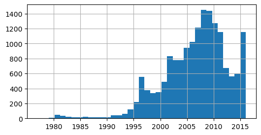

```python
plt.rcParams['figure.figsize'] = [6, 3]
data['year_of_release'].hist(bins=37); # histogram of 1980-2016, 37 baskets
```

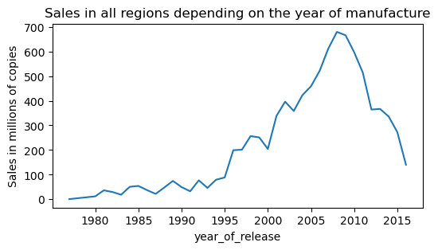

```python
# Sales graph for all regions depending on the year of manufacture

plt.title('Sales in all regions depending on the year of manufacture')
plt.ylabel('Sales in millions of copies')
plt.xlabel('Release years of games')
plt.rcParams['figure.figsize'] = [6, 3]
data.groupby('year_of_release')['total_sales'].sum().plot();
plt.show();
```

#### Sales by platforms.

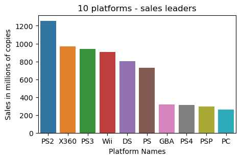

```python
# selecting 10 leading sales platforms for the entire period and build a bar chart

pl_lead = data.groupby(['platform'])['total_sales'].sum().sort_values(ascending=False).head(10)

plt.figure(figsize = (5, 3))
sns.barplot(x=pl_lead.index, y=pl_lead.values, ci=None);
plt.title('10 platforms - sales leaders')
plt.ylabel('Sales in millions of copies')
plt.xlabel('Platform Names')
```

```python
# let's select from the dataframe sales data by year for the above platforms

frm = (data.pivot_table(index=['year_of_release'], columns= 'platform',
       values='total_sales', aggfunc=['sum'])['sum'][pl_lead.index])
frm.tail()
```

| platform year_of_release | PS2 | X360 | PS3 | Wii | DS | PS | GBA | PS4 | PSP | PC |
| --- | --- | --- | --- | --- | --- | --- | --- | --- | --- | --- |
| 2012 | 3.82 | 100.48 | 107.36 | 23.60 | 11.10 | NaN | NaN | NaN | 7.95 | 23.22 |
| 2013 | 1.12 | 88.75 | 113.36 | 10.89 | 1.91 | 0.18 | 0.03 | 25.99 | 3.14 | 12.43 |
| 2014 | 0.50 | 34.81 | 49.98 | 4.16 | 0.53 | NaN | NaN | 100.00 | 0.40 | 13.28 |
| 2015 | 0.40 | 13.15 | 17.83 | 1.31 | 0.01 | NaN | 0.37 | 118.90 | 0.12 | 8.77 |
| 2016 | 0.29 | 2.12 | 3.70 | 3.47 | 0.72 | 2.51 | NaN | 69.25 | 0.90 | 5.25 |

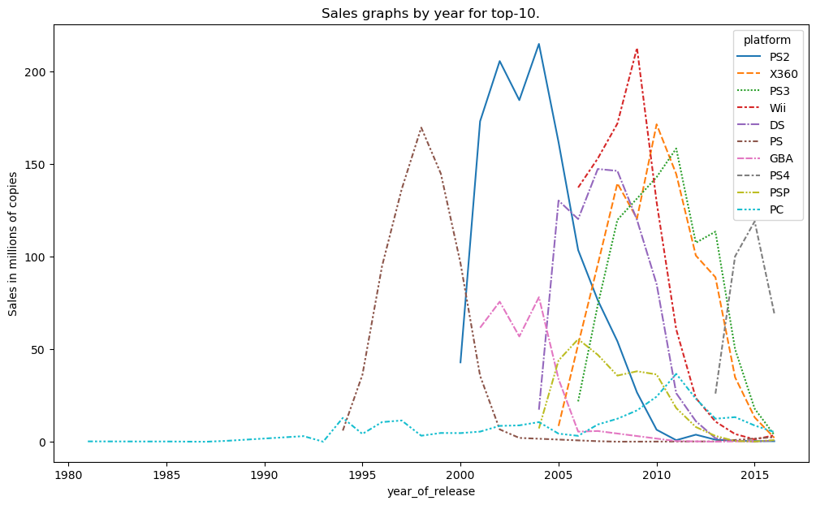

```python
# let's form a sales schedule by year, the color of the lines for each selected platform - see the legend

plt.figure(figsize = (12, 7))   # making the size of the graph bigger
sns.lineplot(data=frm);  # here frm is a previously filtered pivot table
plt.ylabel('Sales in millions of copies')
plt.title('Sales graphs by year for top-10.');
```

```python
# let's collect the sales of non-leaders (except top-10) together, as we did for the leaders

pl_last = data.groupby(['platform'])['total_sales'].sum().sort_values(ascending=False).tail(21)
pl_last
```

```
platform
3DS     259.00
XB      256.75
GB      254.03
NES     251.05
N64     218.68
SNES    200.04
GC      198.93
XOne    159.32
2600     96.98
WiiU     82.19
PSV      54.07
SAT      33.59
GEN      28.35
DC       15.95
SCD       1.86
NG        1.44
WS        1.42
TG16      0.16
3DO       0.10
GG        0.04
PCFX      0.03
Name: total_sales, dtype: float64
```

```python
# let's select from the dataframe sales data by year for the above platforms

frm = (data.pivot_table(index=['year_of_release'], columns= 'platform',
       values='total_sales', aggfunc=['sum'])['sum'][pl_last.index])
frm.tail()
```

| platform year_of_release | 3DS | XB | GB | NES | N64 | SNES | GC | XOne | 2600 | WiiU | ... | SAT | GEN | DC | SCD | NG | WS | TG16 | 3DO | GG | PCFX |
| --- | --- | --- | --- | --- | --- | --- | --- | --- | --- | --- | --- | --- | --- | --- | --- | --- | --- | --- | --- | --- | --- |
| 2012 | 51.76 | 0.60 | NaN | NaN | NaN | NaN | 0.28 | NaN | 0.44 | 17.56 | ... | NaN | NaN | NaN | NaN | NaN | NaN | NaN | NaN | NaN | NaN |
| 2013 | 56.75 | 0.45 | NaN | NaN | 0.33 | NaN | 0.11 | 18.96 | 0.21 | 21.65 | ... | NaN | NaN | NaN | NaN | NaN | NaN | NaN | NaN | NaN | NaN |
| 2014 | 43.95 | NaN | NaN | NaN | NaN | NaN | 0.34 | 54.07 | NaN | 22.03 | ... | NaN | NaN | NaN | NaN | NaN | NaN | NaN | NaN | NaN | NaN |
| 2015 | 27.83 | 0.58 | NaN | NaN | NaN | NaN | 0.53 | 60.14 | NaN | 16.35 | ... | NaN | NaN | NaN | NaN | NaN | NaN | NaN | NaN | NaN | NaN |
| 2016 | 15.21 | 0.06 | 1.03 | NaN | NaN | NaN | NaN | 26.15 | 0.47 | 4.60 | ... | NaN | NaN | NaN | NaN | NaN | NaN | NaN | NaN | NaN | NaN |

5 rows × 21 columns

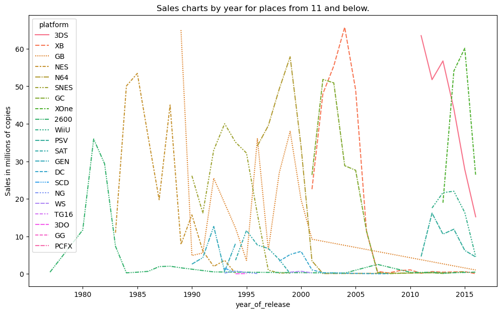

```python
# we will form a sales schedule "not top-10" by year, the color
# of the lines for each selected platform - see the legend

plt.figure(figsize = (12, 7))   # let's make the size of the graph bigger
sns.lineplot(data=frm);  # here frm is a previously filtered pivot table
plt.ylabel('Sales in millions of copies')
plt.title('Sales charts by year for places from 11 and below.');
```

- There are no growing platforms among the "lagging" ones. It was not possible to find solutions to search for growth within the existing assortment.

#### Market assessment for 2017.

- As it was shown above, the market has been falling since 2009, and no growing platforms - regardless of their position in the sales rating - have been found in the dataframe.
- The industry is changing very quickly. Let's introduce the concept of "current period" - that is, we will not take into account games released before 2014 and from the remaining ones we will select those who fall slower than the rest.
- As mentioned in paragraph 1.1, there is no breakdown of sales by year in the dataframe, some downward slope of the charts is normal, since later released games have time to be sold in smaller sizes. The angle of the "normal" slope is unknown, so the analysis will have the right to make an error.

We will select only programs released in 2014 and later (i.e. for 3 years).

```python
# creating a new dataframe, which will reflect only new games released
# in 2014 or later

df10 = data.query('year_of_release > 2013')
```

```python
frm10 = (df10.pivot_table(index=['year_of_release'], columns= 'platform',
       values='total_sales', aggfunc=['sum'])['sum'])
frm10
```

| platform year_of_release | 2600 | 3DS | DS | GB | GBA | GC | PC | PS | PS2 | PS3 | PS4 | PSP | PSV | Wii | WiiU | X360 | XB | XOne |
| --- | --- | --- | --- | --- | --- | --- | --- | --- | --- | --- | --- | --- | --- | --- | --- | --- | --- | --- |
| 2014 | NaN | 43.95 | 0.53 | NaN | NaN | 0.34 | 13.28 | NaN | 0.50 | 49.98 | 100.00 | 0.40 | 11.90 | 4.16 | 22.03 | 34.81 | NaN | 54.07 |
| 2015 | NaN | 27.83 | 0.01 | NaN | 0.37 | 0.53 | 8.77 | NaN | 0.40 | 17.83 | 118.90 | 0.12 | 6.25 | 1.31 | 16.35 | 13.15 | 0.58 | 60.14 |
| 2016 | 0.47 | 15.21 | 0.72 | 1.03 | NaN | NaN | 5.25 | 2.51 | 0.29 | 3.70 | 69.25 | 0.90 | 4.51 | 3.47 | 4.60 | 2.12 | 0.06 | 26.15 |

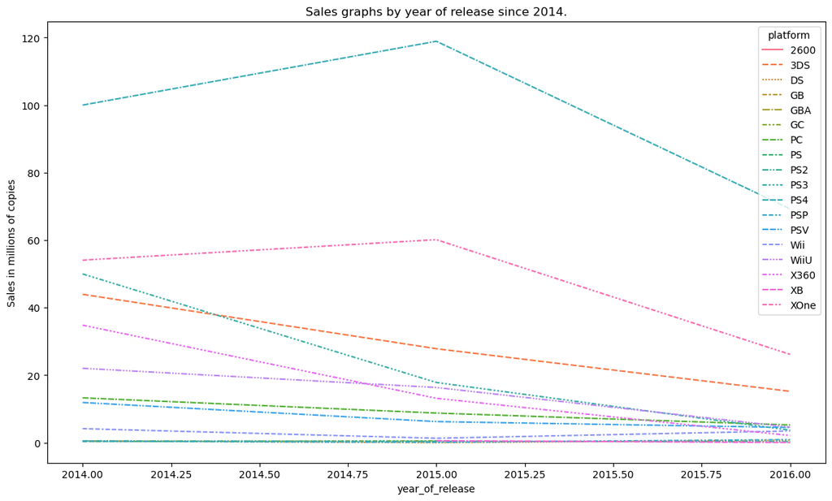

```python
# sales graph for the years from 2014, the color of the lines for each selected platform - see the legend

plt.figure(figsize = (14, 8))   # let's make the size of the graph bigger
sns.lineplot(data=frm10);  # here frm10 is a previously filtered pivot table
plt.ylabel('Sales in millions of copies')
plt.title('Sales graphs by year of release since 2014.');
```

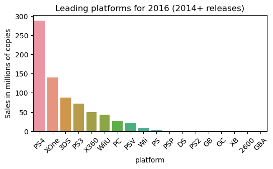

```python
# grouping the data and printing a bar chart

pl = (df10.groupby('platform')['total_sales'].sum().sort_values(ascending=False))
sns.barplot(x=pl.index, y=pl.values, ci=None)
plt.xticks(rotation = 45)
plt.ylabel('Sales in millions of copies')
plt.title('Leading platforms for 2016 (2014+ releases)');
plt.show()
```

- In the market that has been falling since 2009, in the interval between 2014 and 2016, the release of PS4 and XOne platform games by 2016 have the largest number of sales by cumulative total and can be recognized as the most promising.

#### Making box plot diagrams.

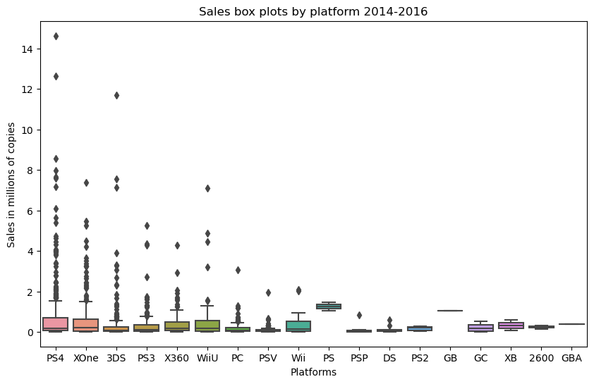

```python
# Based on the data for 2014-2016, we will build boxplots, the order is in descending order of sales volumes 2014-2016

plt.figure(figsize = (10, 6))
sns.boxplot(data = df10, x='platform', y='total_sales', order=pl.index) # pl is built in the cell above
plt.ylabel('Sales in millions of copies')
plt.xlabel('Platforms')
plt.title('Sales box plots by platform 2014-2016');
```

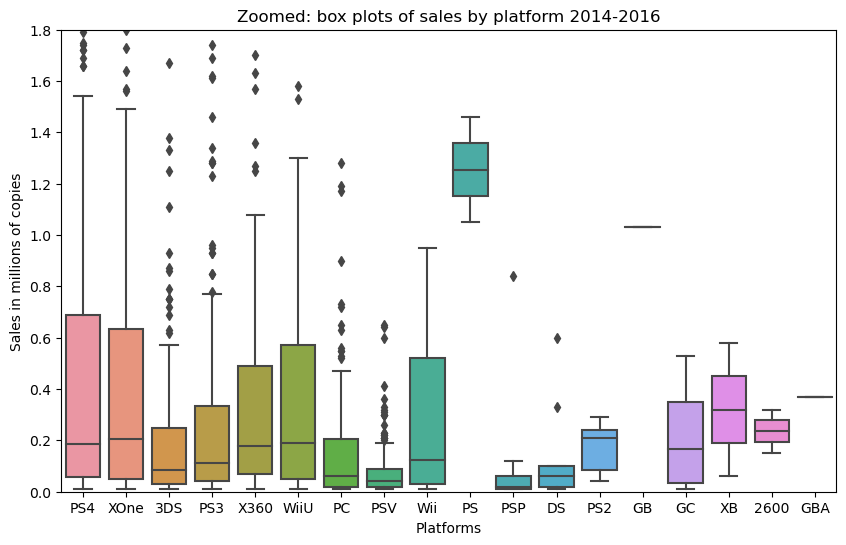

```python
# printing box-and-whiskers diagram with the upper part cut off

plt.figure(figsize = (10, 6))
plt.ylim([0, 1.8])                      # cut off the top with emissions
sns.boxplot(data=df10, x ='platform', y ='total_sales', order=pl.index)
plt.ylabel('Sales in millions of copies')
plt.xlabel('Platforms')
plt.title('Zoomed: box plots of sales by platform 2014-2016');
```

### The impact of user reviews and critics. Correlation.

#### Correlation across 9 platforms with critics' ratings.

```python
# To place the graphs in 3x3 cells, let's take the top 9 leader platforms

list_platforms = df10.groupby('platform')['total_sales'].sum().head(9).index
list_platforms
```

```
Index(['2600', '3DS', 'DS', 'GB', 'GBA', 'GC', 'PC', 'PS', 'PS2'], dtype='object', name='platform')
```

```python
%%capture
# suppressing the output from this cell so that service information is not printed with graphs


def cofunc(pl, ax_n, e_sc, r_sc):     # next we will call this function
    remarks = df10[df10['platform'] == pl][[e_sc, 'total_sales']]
    plt.figure(figsize = (2.5,2.5))
    sns.scatterplot(data=remarks, x=e_sc, y='total_sales', s=100, legend=False, ax=ax_n)
    ax_n.set_xlabel(r_sc)
    ax_n.set_ylabel('Sales million pieces')
    k = remarks[[e_sc,'total_sales']].corr().round(3)['total_sales'][0]
    ax_n.set_title(f'Platform {pl}, correlation {k}');


fig_3 = plt.figure(figsize=(15,15)) # dimensions of the field where the diagrams will be displayed
ax1 = fig_3.add_subplot(3,3,1) # arrangement of diagrams in cells
ax2 = fig_3.add_subplot(3,3,2)
ax3 = fig_3.add_subplot(3,3,3)
ax4 = fig_3.add_subplot(3,3,4)
ax5 = fig_3.add_subplot(3,3,5)
ax6 = fig_3.add_subplot(3,3,6)
ax7 = fig_3.add_subplot(3,3,7)
ax8 = fig_3.add_subplot(3,3,8)
ax9 = fig_3.add_subplot(3,3,9)

axes = [ax1,ax2,ax3,ax4,ax5,ax6,ax7,ax8,ax9]

for i in range(len(list_platforms)):
    cofunc(pl=list_platforms[i], ax_n=axes[i], e_sc = 'critic_score', r_sc = 'critic scores');
```

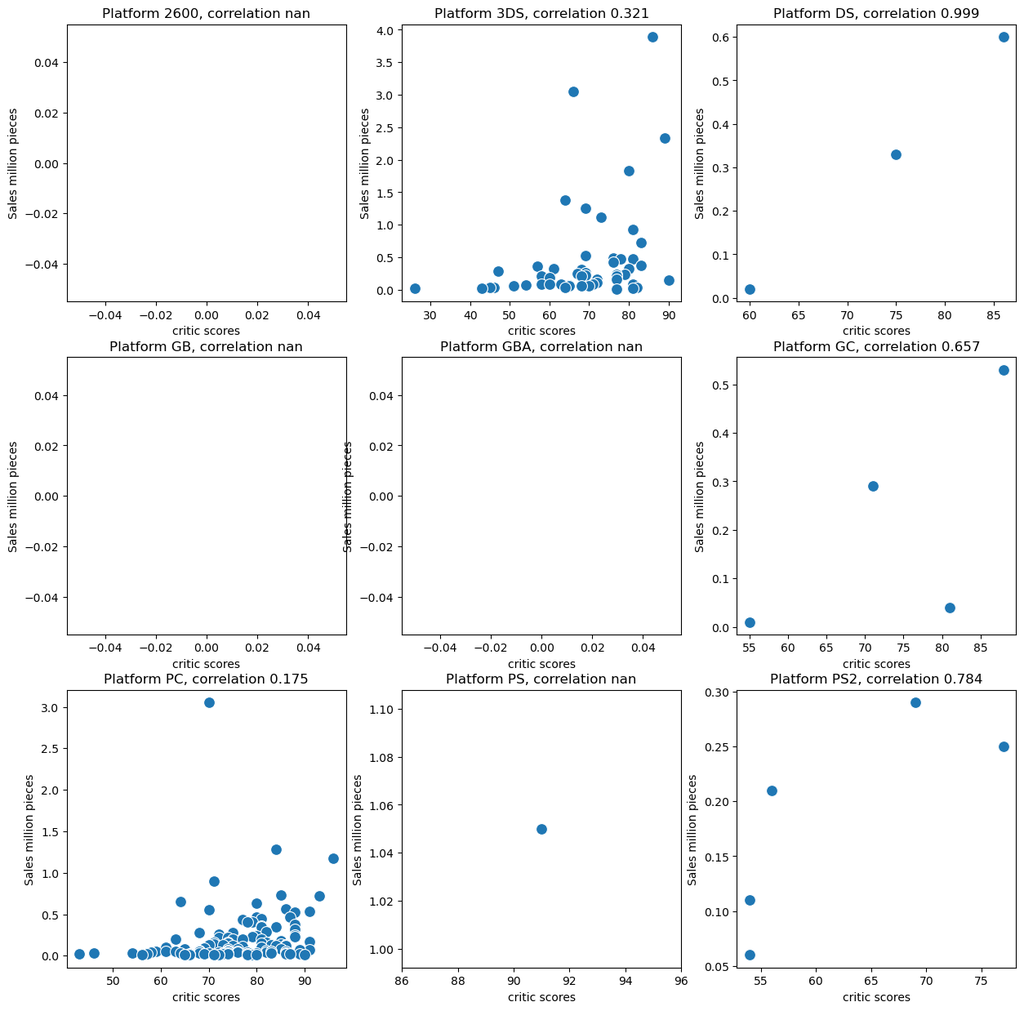

```python
fig_3 # printing a "clean" graph
```

#### Correlation across 9 platforms with user ratings.

```python
%%capture
# suppressing output from this cell so that service information is not printed with graphs


def cofunc(pl, ax_n, e_sc, r_sc):     # later we will call this function
    remarks = df10[df10['platform'] == pl][[e_sc, 'total_sales']]
    plt.figure(figsize = (2.5,2.5))
    sns.scatterplot(data=remarks, x=e_sc, y='total_sales', s=100, legend=False, ax=ax_n)
    ax_n.set_xlabel(r_sc)
    ax_n.set_ylabel('Sales million pieces')
    k = remarks[[e_sc,'total_sales']].corr().round(3)['total_sales'][0]
    ax_n.set_title(f'Platform {pl}, correlation {k}');


fig_4 = plt.figure(figsize=(15,15)) # size of the field where the charts will be displayed
ax1 = fig_4.add_subplot(3,3,1) # putting diagrams into cells
ax2 = fig_4.add_subplot(3,3,2)
ax3 = fig_4.add_subplot(3,3,3)
ax4 = fig_4.add_subplot(3,3,4)
ax5 = fig_4.add_subplot(3,3,5)
ax6 = fig_4.add_subplot(3,3,6)
ax7 = fig_4.add_subplot(3,3,7)
ax8 = fig_4.add_subplot(3,3,8)
ax9 = fig_4.add_subplot(3,3,9)

axes = [ax1,ax2,ax3,ax4,ax5,ax6,ax7,ax8,ax9]

for i in range(len(list_platforms)):
    cofunc(pl=list_platforms[i], ax_n=axes[i], e_sc = 'user_score', r_sc = 'user scores');
```

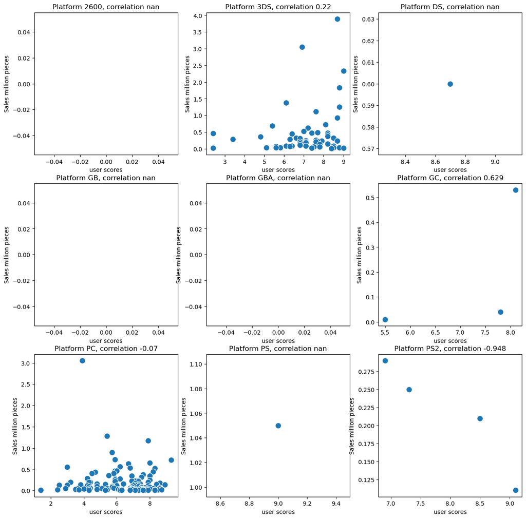

```python
fig_4 # printing "clean" graph
```

#### Analysis of sales by genre within year of release 2014+.

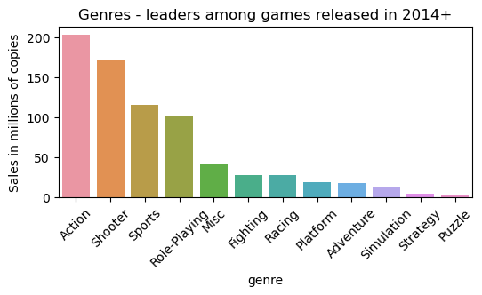

```python
# printing a bar chart for sales amounts by genre, selecting the data

gn = df10.groupby('genre')['total_sales'].sum().sort_values(ascending=False)

# setting the sizes of our diagram
fig, ax = plt.subplots(figsize=(6, 2.5))

plt.ylabel('Sales in millions of copies')
plt.title('Genres - leaders among games released in 2014+');
plt.xticks(rotation = 45)

# printing the bar chart
sns.barplot(x=gn.index, y=gn.values, ax=ax, ci=None)
plt.show()
```

```python
# grouping data based on genre (year of release 2014+)

fg = df10.pivot_table(index=['genre'], columns='platform', values='total_sales', aggfunc=['sum', 'median'])
fgs = fg['sum'].sort_values(by='WiiU', ascending=False)    # data on sales amounts
fgm = fg['median'].sort_values(by='WiiU', ascending=False) # median sales data
fg # platforms and genres, sales in the cells, full table
```

| platform genre | sum 2600 | sum 3DS | sum DS | sum GB | sum GBA | sum GC | sum PC | sum PS | sum PS2 | sum PS3 | ... | median PS2 | median PS3 | median PS4 | median PSP | median PSV | median Wii | median WiiU | median X360 | median XB | median XOne |
| --- | --- | --- | --- | --- | --- | --- | --- | --- | --- | --- | --- | --- | --- | --- | --- | --- | --- | --- | --- | --- | --- |
| Action | NaN | 22.06 | NaN | NaN | 0.37 | 0.29 | 5.34 | 1.05 | NaN | 19.54 | ... | NaN | 0.105 | 0.150 | 0.02 | 0.040 | 0.060 | 0.130 | 0.160 | NaN | 0.140 |
| Adventure | NaN | 1.57 | NaN | NaN | NaN | NaN | 0.39 | NaN | NaN | 1.98 | ... | NaN | 0.050 | 0.070 | 0.01 | 0.020 | 0.140 | 0.070 | 0.100 | NaN | 0.060 |
| Fighting | NaN | 8.10 | NaN | NaN | NaN | NaN | 0.10 | NaN | 0.21 | 2.89 | ... | 0.210 | 0.130 | 0.160 | NaN | 0.090 | 0.030 | 2.940 | 0.080 | NaN | 0.310 |
| Misc | NaN | 3.85 | 0.04 | NaN | NaN | NaN | 0.05 | NaN | NaN | 8.35 | ... | NaN | 0.075 | 0.060 | 0.01 | 0.060 | 0.950 | 0.110 | 0.230 | NaN | 0.180 |
| Platform | NaN | 3.98 | 0.03 | 1.03 | NaN | NaN | 0.06 | NaN | 0.29 | 0.76 | ... | 0.290 | 0.110 | 0.260 | NaN | 0.020 | NaN | 0.510 | 0.095 | NaN | 0.130 |
| Puzzle | NaN | 0.87 | 0.33 | NaN | NaN | NaN | NaN | NaN | NaN | 0.04 | ... | NaN | 0.040 | 0.020 | NaN | 0.030 | NaN | 0.020 | NaN | NaN | NaN |
| Racing | 0.32 | NaN | NaN | NaN | NaN | NaN | 0.64 | NaN | 0.27 | 1.00 | ... | 0.135 | 0.080 | 0.205 | NaN | 0.040 | 0.015 | 7.090 | 0.130 | NaN | 0.125 |
| Role-Playing | NaN | 40.05 | 0.10 | NaN | NaN | 0.01 | 4.87 | NaN | NaN | 6.69 | ... | NaN | 0.090 | 0.200 | 0.04 | 0.065 | NaN | 0.335 | 0.490 | NaN | 0.320 |
| Shooter | NaN | 0.07 | NaN | NaN | NaN | NaN | 6.04 | NaN | 0.06 | 12.17 | ... | 0.060 | 0.425 | 0.820 | NaN | 0.640 | 0.020 | 0.370 | 0.380 | 0.06 | 0.910 |
| Simulation | NaN | 4.32 | 0.06 | NaN | NaN | NaN | 6.59 | NaN | NaN | 0.39 | ... | NaN | 0.195 | 0.210 | NaN | 0.010 | NaN | NaN | 0.060 | NaN | 0.120 |
| Sports | 0.15 | 1.34 | 0.10 | NaN | NaN | 0.57 | 0.93 | 1.46 | 0.25 | 17.64 | ... | 0.250 | 0.155 | 0.405 | 0.12 | 0.055 | 0.560 | 0.410 | 0.180 | 0.58 | 0.250 |
| Strategy | NaN | 0.78 | 0.60 | NaN | NaN | NaN | 2.29 | NaN | 0.11 | 0.06 | ... | 0.110 | 0.060 | 0.080 | NaN | 0.035 | NaN | NaN | NaN | NaN | 0.125 |

12 rows × 36 columns

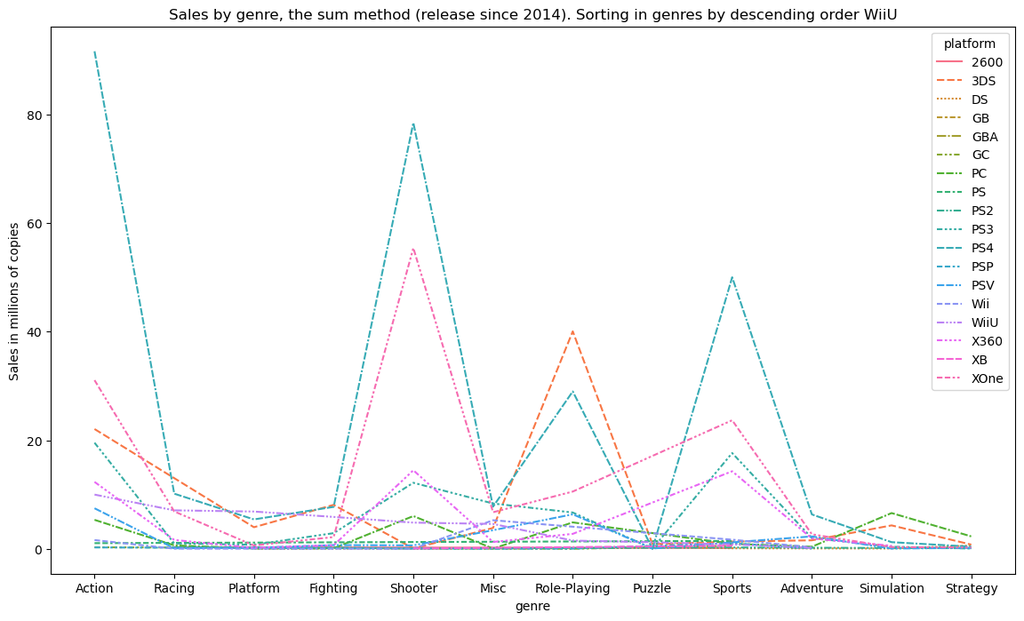

```python
# forming sales chart for the years from 2014, the color of lines for each selected platform - see the legend

plt.figure(figsize = (14, 8))   # let's make the size of the graph bigger
sns.lineplot(data=fgs);  # here fg is the pivot table filtered above
plt.ylabel('Sales in millions of copies')
plt.title('Sales by genre, the sum method (release since 2014). Sorting in genres by descending order WiiU');
```

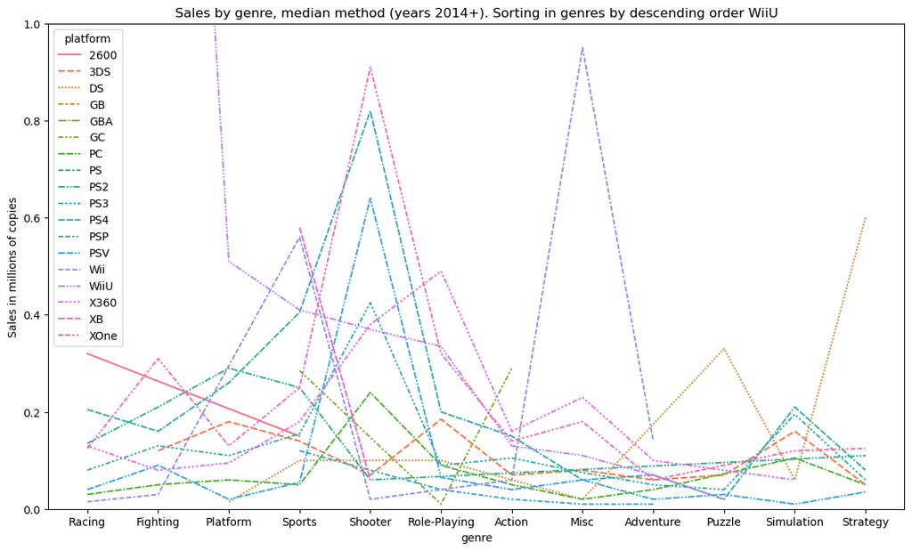

```python
# form a sales grapgh for years 2014+, the color of the lines for each selected platform - see the legend

plt.figure(figsize = (14, 8))   # let's make the size of the graph bigger
sns.lineplot(data=fgm);  # here fg is the pivot table filtered above
plt.ylim([0, 1])  # cut off the top with emissions
plt.ylabel('Sales in millions of copies')
plt.title('Sales by genre, median method (years 2014+). Sorting in genres by descending order WiiU');
```

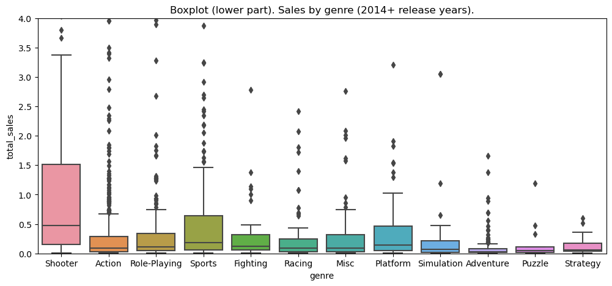

```python
# printing boxplot ("box-and-whisker")

rb = df10[['genre','total_sales']]
plt.figure(figsize = (12, 5))
plt.title('Boxplot (lower part). Sales by genre (2014+ release years).');
plt.ylim([0, 4])  # cut off the top with emissions
sns.boxplot(x="genre", y="total_sales", data=rb);
```

### Step 4. User portraits by region.

#### The most popular platforms (top 5).

```
TOP-5 platforms by 3 regions and "the rest" (2014+ release years)
```

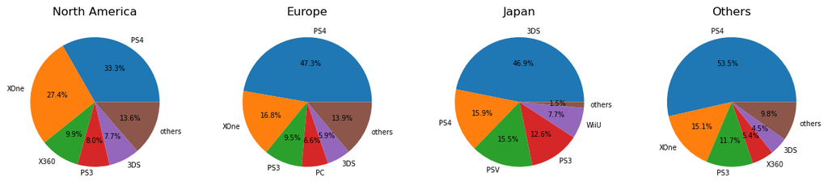

```python
# creating a function for grouping data and selecting from columns for charts
def rund(reg_sales):
    f3 = df10.pivot_table(index=['platform'], values=['na_sales', 'eu_sales', 'jp_sales', 'other_sales'], \
                      aggfunc=['sum'])['sum'].sort_values(by=reg_sales, ascending=False)
    r_sales = list(f3[reg_sales])
    s = sum(r_sales[5:])
    r_sales = list(r_sales[:5])
    r_sales.append(s)
    plats = list(f3.index[:5])
    plats.append('others')
    return r_sales, plats


fig_1 = plt.figure(figsize=(15,3)) # dimensions of the field where diagrams will be displayed
ax1 = fig_1.add_subplot(1,4,1) # putting diagrams into cells
ax2 = fig_1.add_subplot(1,4,2)
ax3 = fig_1.add_subplot(1,4,3)
ax4 = fig_1.add_subplot(1,4,4)

# calling the function and taking numbers and platforms from a tuple
ax1.pie(rund('na_sales')[0], labels=rund('na_sales')[1],autopct='%1.1f%%',textprops={'fontsize':7})
ax2.pie(rund('eu_sales')[0], labels=rund('eu_sales')[1],autopct='%1.1f%%',textprops={'fontsize':7})
ax3.pie(rund('jp_sales')[0], labels=rund('jp_sales')[1],autopct='%1.1f%%',textprops={'fontsize':7})
ax4.pie(rund('other_sales')[0], labels=rund('other_sales')[1],autopct='%1.1f%%',textprops={'fontsize':7})

ax1.set_title('North America') # headings for each chart
ax2.set_title('Europe')
ax3.set_title('Japan')
ax4.set_title('Others');
print('\nTOP-5 platforms by 3 regions and "the rest" (2014+ release years)');
```

- PS4 is the leader in North America, XOne is in second place. In Europe, the unequivocal leader is PS4, followed by XOne with a lag. In Japan, 3DS is the absolute leader, followed by PS4 and PSV. In other regions, the total leader is PS4 (as in Europe) and behind it with a margin of XOne, and PS3 is in 3rd place. Interestingly, in Japan, almost the entire market is disassembled under 5 leaders, others occupy a very small share.

#### The most popular genres (top 5).

```
TOP-5 genres by 3 regions and "the rest" (2014+ release years)
```

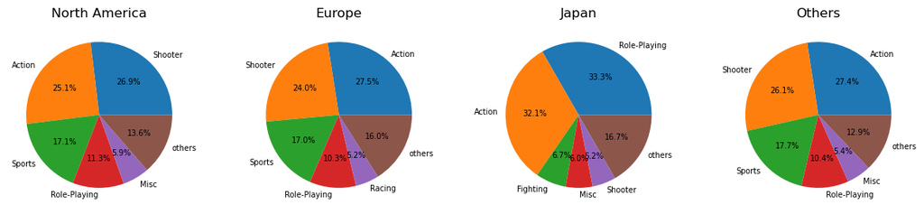

```python
# creating a function for grouping data and selecting from columns for charts
def rund2(reg_sales):
    f3 = df10.pivot_table(index=['genre'], values=['na_sales', 'eu_sales', 'jp_sales', 'other_sales'], \
                      aggfunc=['sum'])['sum'].sort_values(by=reg_sales, ascending=False)
    r_sales = list(f3[reg_sales])
    s = sum(r_sales[5:])
    r_sales = list(r_sales[:5])
    r_sales.append(s)
    gen = list(f3.index[:5])
    gen.append('others')
    return r_sales, gen


fig_1 = plt.figure(figsize=(15,3)) # dimensions of field where the diagrams will be displayed
ax1 = fig_1.add_subplot(1,4,1) # setting diagrams into sells
ax2 = fig_1.add_subplot(1,4,2)
ax3 = fig_1.add_subplot(1,4,3)
ax4 = fig_1.add_subplot(1,4,4)

# function call and taking numbers and platforms from a tuple
ax1.pie(rund2('na_sales')[0], labels=rund2('na_sales')[1],autopct='%1.1f%%',textprops={'fontsize': 7})
ax2.pie(rund2('eu_sales')[0], labels=rund2('eu_sales')[1],autopct='%1.1f%%',textprops={'fontsize': 7})
ax3.pie(rund2('jp_sales')[0], labels=rund2('jp_sales')[1],autopct='%1.1f%%',textprops={'fontsize': 7})
ax4.pie(rund2('other_sales')[0], labels=rund2('other_sales')[1],autopct='%1.1f%%',textprops={'fontsize':7})

ax1.set_title('North America') # headings for each chart
ax2.set_title('Europe')
ax3.set_title('Japan')
ax4.set_title('Others');
print('\nTOP-5 genres by 3 regions and "the rest" (2014+ release years)');
```

- Shooter and Action genres are leading in North America. Action and Shooter genres are leading in Europe. In Japan, the leaders are Role-Playing and Action. In the rest of the world, the Action and Shooter genres are leading. The Sports genre is popular everywhere (3rd place), but not in Japan, the Japanese have the "other" genres in 3rd place.

#### Impact of ESRB rating on sales in certain regions.

Since about a third of the games do not have the American voluntary ESRB rating, the value "no_esrb" was written in this field in the additional processing section for the places of omissions.

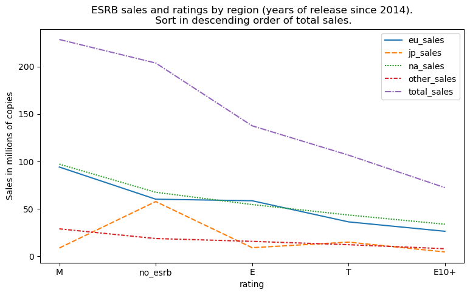

```python
# we are collecting a summary table of the ESRB rating

fg = (df10.pivot_table(index=['rating'],values=['na_sales','eu_sales','jp_sales','other_sales','total_sales'],
      aggfunc=['sum']))['sum']
fg = fg.sort_values(by='total_sales', ascending=False) # sorting data by total sales
plt.figure(figsize = (9, 5))
plt.ylabel('Sales in millions of copies')
plt.title('ESRB sales and ratings by region (years of release since 2014).\n Sort in descending order of total sales.')
sns.lineplot(data=fg);
```

- According to ESRB ratings, North American and European data are almost the same. The rest of the regions practically repeat this trend, only on a smaller scale (the curve is shifted down relative to Europe and North America).
- And the Japanese market has its own specifics: its line has a peak in the field of programs with the label no_esrb.
- The no_esrb label has almost the same level of sales in the European, North American and Japanese markets.

```python
# service code
temp = df10.copy()
print(temp.rating.isna().sum(), temp.rating.isna().sum()/len(temp))
temp.rating.value_counts()
```

```
0 0.0
```

```
no_esrb    774
T          287
M          269
E          236
E10+       188
Name: rating, dtype: int64
```

### Step 5. Hypothesis testing.

A brief explanation of the process.

1. The process consists in comparing the probability of the null hypothesis H0 (usually it is the equality of the mean values of two samples) and the alternative hypothesis H1, which in terms of probability theory is the complement of H0 (in sum their probabilities are equal to 1).
2. The ttest function calculates the P-value. P-value is the probability of obtaining a criterion statistic value equal to the observed one or more atypical compared to the observed one, provided that the null hypothesis is correct.
3. In our experiments, the P-value is calculated for two samples and further, if this probability (the probability of equality, coincidence) is less than the alpha threshold value, we reject the null hypothesis and accept an alternative one.

#### Hypothesis: the average user ratings of the Xbox One and PC platforms are the same.

```python
df10['platform'].unique() # platform name codes in our database
```

```
array(['PS4', '3DS', 'XOne', 'WiiU', 'PS3', 'X360', 'PC', 'Wii', 'PSV',
       'PS', 'GB', 'PSP', 'DS', 'XB', 'GC', 'GBA', '2600', 'PS2'],
      dtype=object)
```

```python
# we believe that Xbox One is XOne, we will allocate 2 collections for analysis. NaN is excluded
# since part of numbers does not have a dot and is perceived as integers, we translate it into float

x1 = df10[df10['user_score'].notna()].query('platform == "XOne"')['user_score']
x2 = df10[df10['user_score'].notna()].query('platform == "PC"')['user_score']
```

H_0: The average user rating of the Xbox One platform is equal to the rating of the PC platform

H_1: The average user rating of the Xbox One platform is NOT equal to the rating of the PC

alpha = 0.01

```python
# results = calling a method to test the hypothesis
results = st.ttest_ind(x1, x2, equal_var=False)
# alpha = setting the significance level value
alpha = 0.01
# output of the p-value value to the screen
print(results.pvalue)
# conditional operator with the output of a response string
if results.pvalue < alpha:
    print('We reject the null hypothesis.')
else:
    print('Failed to reject the null hypothesis.')
```

```
0.13286822531130538
Failed to reject the null hypothesis.
```

```python
# let's show the average estimates of Xbox One and PC users

round(x1.mean(), 2), round(x2.mean(), 2)
```

```
(6.59, 6.31)
```

#### Hypothesis: average user ratings of Action and Sports genres are different.

```python
# let's select 2 collections with data for statistical analysis from the dataframe

x1 = df10[df10['user_score'].notna()].query('genre == "Action"')['user_score']
x2 = df10[df10['user_score'].notna()].query('genre == "Sports"')['user_score']
```

H_0: The average user rating of the Action genre is equal to the rating of the Sports genre

H_1: The average user rating of the Action genre is NOT equal to the rating of the Sports

alpha = 0.01

```python
# results = calling the method to test a hypothesis
results = st.ttest_ind(x1, x2, equal_var=False)
# alpha = setting the significance level value
alpha = 0.01
# getting of the p-value value on the screen
print(results.pvalue)
# conditional operator with the output of a response string
if results.pvalue < alpha:
    print('We reject the null hypothesis.')
else:
    print('Failed to reject the null hypothesis.')
```

```
2.537777752423587e-13
We reject the null hypothesis.
```

Based on the available data, at the significance level of 1%, there are grounds to reject the null hypothesis about the equality of the average values of user ratings (reviews) of the Action and Sports genres in favor of an alternative hypothesis.

```python
# print the average estimates of users of the Action and Sports genres

round(x1.mean(), 2), round(x2.mean(), 2)
```

```
(6.77, 5.36)
```

## Conclusions.

On the chart of the scope of the PS4, their sales are large due to emissions (see the chart "Platform leaders for 2016 (2014+ releases)"). That is, they have "star games" that contribute to gross sales, but the second half of the list are stable middle-class, already without emissions.

In North America, the PS4 is in the lead, with XOne in second place. In Europe, the unequivocal leader is PS4, followed by XOne with a lag. In Japan, 3DS is the absolute leader, followed by PS4 and PSV. In other regions, the total leader is PS4 (as in Europe) and behind it with a margin of XOne, and PS3 is in 3rd place. Interestingly, in Japan, almost the entire market is disassembled under 5 leaders, others occupy a very small share.

Shooter and Action genres are leading in North America. Action and Shooter genres are leading in Europe. In Japan, the leaders are Role-Playing and Action. In the rest of the world, the Action and Shooter genres are leading. The Sports genre is popular everywhere (3rd place), but not in Japan, the Japanese have the "other" genres in 3rd place.

According to the ESRB ratings, North American and European data are almost the same. The rest of the regions practically repeat this trend, only on a smaller scale (the curve is shifted down relative to Europe and North America). And the Japanese market has its own specifics: its line has a peak in the field of programs with the label no_esrb. The no_esrb label has almost the same level of sales in the European, North American and Japanese markets.